# iniproyecto Tratamiento de los datos

Tratamiento de los Datos. Grado en Ciencia de Datos- UV

Juan Antonio Zarceño Gonzalez, Carla Giménez Piqueres, María José Monsonís Llopis, Alejandro Manuel Tejera Nuñez, Rubén García Lajara

2026-05-06

### 1 Introducción

En este trabajo, se realiza un Análisis Exploratorio de Datos (EDA) usando un conjunto de registros de actividad de la plataforma educativa Aula Virtual. Este tipo de datos recoge información detallada sobre las acciones que llevan a cabo los usuarios en el entorno virtual, permitiendo analizar su comportamiento y el uso de los recursos disponibles.

El dataset contiene registros anonimizados con variables como la fecha y hora de la acción, el identificador del usuario, el contexto del evento (curso, tarea, cuestionario, etc.), el componente al que pertenece la acción, el tipo de evento realizado, una breve descripción de la actividad, y datos técnicos adicionales como el origen del acceso y la dirección IP. Estos datos permiten estudiar la interacción de los usuarios con el contenido académico y los patrones de navegación en la plataforma.

El objetivo principal de este trabajo es explorar las características del conjunto de datos, identificar patrones de comportamiento y analizar la frecuencia y tipo de eventos registrados. Para ello, se lleva a cabo un proceso que incluye cargar y preprocesar los datos, revisar posibles valores perdidos o inconsistencias, y después aplicar técnicas de análisis univariante y multivariante mediante herramientas estadísticas y visualizaciones.

A través de este análisis, se busca obtener una visión general sobre el uso de Moodle, además de detectar posibles tendencias en el acceso a contenidos, la realización de actividades o la interacción con diversos recursos educativos. Este tipo de estudio puede ser útil para entender mejor el comportamiento de los usuarios y contribuir a la mejora de los entornos virtuales de aprendizaje.

Para orientar el análisis y extraer información relevante, se han planteado una serie de preguntas iniciales que servirán como guía a lo largo del estudio. Estas cuestiones surgen de una primera exploración del dataset y buscan identificar patrones de comportamiento, relaciones entre variables y tendencias en el uso de la plataforma.

Preguntas:

En cuanto a la actividad semanal: ¿Qué días de la semana se usa más el aula virtual y cuánto cae el uso el sábado y el domingo?

En cuanto a los roles: Si comparamos el uso de las notas (los alumnos para verlas y los profes para ponerlas), ¿quién interactúa más con esa sección proporcionalmente a su grupo?

En cuanto al comportamiento del usuario (Sistema): El apartado que más se usa, ¿es de “entrar y salir” (consultas rápidas) o es de gente que se queda mucho tiempo navegando por todo el curso?

En cuanto a deducción de perfiles: Cuando vemos mucha actividad en “Tareas”, ¿podemos saber cuántos son profesores solo por cómo se mueven por el resto de la web, o es imposible distinguirlos de los alumnos?

¿Qué porcentaje de la clase entra solo a “mirar” (ver archivos o avisos) comparado con los que realmente “hacen” algo (subir tareas o participar)?

¿Existen usuarios con comportamientos atípicos en la plataforma?

### 2 Importación

```r
#primero cargaremos los datos
logs <- read.csv("data/logs_moodle_anon.csv")
```

### 3 Figura

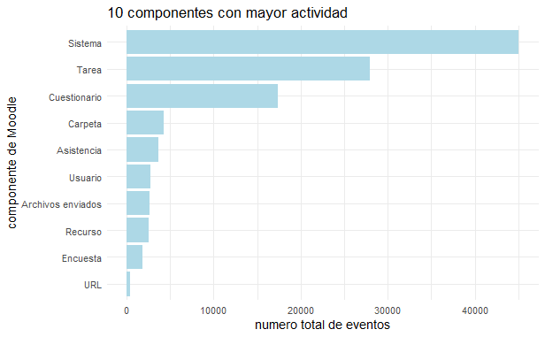

```r
library(ggplot2)
library(dplyr)
resumen_datos<- logs %>%
  count(Componente) %>%
  slice_max(n, n=10) #cuenta los 10 componentes con más registros para no saturar el grafico

ggplot(data= resumen_datos, aes(x= reorder(Componente, n), y=n))+
  geom_col(fill='lightblue')+
  coord_flip() + #girar el grafico para que se lean bien los nombres
  labs(title= '10 componentes con mayor actividad',
       x='componente de Moodle',  y= 'numero total de eventos') +
  theme_minimal()
```

En la Figura @ref(fig:fig-componentes) se puede ver de forma muy clara cómo se reparte el uso del aula virtual. Lo que más llama la atención es que la actividad no es equilibrada: el componente “Sistema” tiene la barra más alta con mucha diferencia. Esto tiene sentido, ya que cada vez que un usuario entra o se mueve por las secciones, el sistema lo registra.

Después de la navegación básica, lo que más movimiento genera son las “Tareas” y los “Cuestionarios”. Sus barras son altas porque son las herramientas que los alumnos usan para trabajar y examinarse. Por el contrario, el resto de componentes (como “Carpeta” o “Asistencia”) tienen barras muy pequeñas, lo que indica que se usan de forma mucho más específica o menos frecuente.

### 4 Tabla

```r
df_componentes<- as.data.frame(table(logs$Componente))
colnames(df_componentes)<- c("Componente", "Frecuencia")

knitr::kable(df_componentes,
             caption="Frecuencia de uso por componentes del aula virtual",
             booktabs=TRUE)
```

Frecuencia de uso por componentes del aula virtual

| Componente | Frecuencia |
| --- | --- |
| Actividad del curso | 2 |
| Aplicación de Actas (XSLX) | 17 |
| Archivos enviados | 2638 |
| Asistencia | 3637 |
| Carpeta | 4303 |
| Comentarios de la entrega | 23 |
| Cuestionario | 17380 |
| Diálogo | 71 |
| Encuesta | 1855 |
| Entregas de texto en línea | 108 |
| Foro | 313 |
| Herramienta Externa | 104 |
| Hoja de cálculo Excel | 5 |
| Informe del calificador | 309 |
| Informe general | 12 |
| Papelera de reciclaje | 82 |
| Participación en el curso | 1 |
| Recurso | 2549 |
| Registros | 9 |
| Sistema | 45073 |
| Taller | 1 |
| Tarea | 27983 |
| URL | 349 |
| Usuario | 2771 |
| Vista Simple | 146 |
| Wooclap | 5 |

En la tabla @ref(tab:tabla-componentes) se puede observar el recuento de todos los casos dentro de la columna “Componente”, donde se muestra el número de veces que aparece cada uno de ellos. A diferencia de la gráfica, aquí no se representa de forma visual, sino que se pueden ver los valores exactos, lo que permite analizar con más precisión la actividad de los usuarios.Se vuelve a apreciar claramente que la actividad no se distribuye de forma uniforme, ya que el componente “Sistema” presenta una diferencia muy grande respecto al resto, acumulando el mayor número de eventos. Esto es coherente con lo comentado anteriormente, porque incluye muchas acciones distintas como el acceso o la navegación dentro del aula virtual, lo que hace que se registre constantemente.

Después, aparecen los componentes “Tarea” y “Cuestionario”, que también tienen valores bastante altos, aunque alejados de “Sistema”. Esto se debe a que forman parte fundamental del desarrollo del curso, ya que los alumnos los utilizan para entregar actividades y realizar evaluaciones, generando así bastantes interacciones.Por otro lado, se pueden ver componentes con valores intermedios como “Carpeta”, “Asistencia”, “Usuario” o “Archivos enviados”, que aunque no destacan tanto, sí tienen cierta presencia dentro del uso habitual de la plataforma. Finalmente, hay otros componentes con valores muy bajos, lo que indica que su uso es mucho más limitado o puntual.

La tabla permite ver de forma más detallada cómo se reparte la actividad entre los distintos componentes y confirmar lo que ya se observaba en la gráfica, que la mayoría de interacciones se concentran en unos pocos elementos principales del aula virtual

**Fase 2**

- PREGUNTA 1 En cuanto a la actividad semanal: ¿Qué días de la semana se usa más el aula virtual y cuánto cae el uso el sábado y el domingo?

Para poder responder correctamente la pregunta en relacion con la actividad semanal, mediante un ggplot, comprobaremos el apartado fecha de nuestro data frame para poder sacar conclusiones adecuadas.

```r
#primero cargamos las librerias que consideramos necesarias para poder crear una tabla que nos compare la actividad en el aula virtual cada dia
library(dplyr)
library(ggplot2)
library(lubridate)

#la segunda parte es el procesamiento de los datos
logs_semanal <- logs %>%
  mutate(
    #Como vemos en el df la columna hora lleva tanto la fecha como la hora, lo que queremso hacer con la funcion dmy_hms es convertir solo la fecha y eliminar la hora
    Fecha_dt = dmy_hms(Hora),
    # extraemos el día de la semana (lunes como día 1, martes como dia 2 y asi hasta el domingo)
    Dia_Semana = wday(Fecha_dt, label = TRUE, abbr = FALSE, week_start = 1)
  ) %>%
  # Contamos cuántos eventos hay por día para poder crear las columnas de la grafica
  group_by(Dia_Semana) %>%
  summarise(Total_Eventos = n())

#La ultima parte ya es crear la grafica con los datos obtenidos
ggplot(logs_semanal, aes(x = Dia_Semana, y = Total_Eventos, fill = Dia_Semana)) + geom_col(show.legend = FALSE) + scale_fill_manual(values = c("lightblue","lightyellow","lavender","aliceblue","pink","lightcyan","powderblue")) + labs(title = "Actividad semanal en el aula virtual", subtitle = "Comparación de los dias respecto a la actividad en el aula virtual", x = "Dia de la semana", y = "Numero de registros") +   theme_minimal()
```

[output not shown]

Respecto al fin de semana, se nota una caida significativa. Si comparamos un dia lectivo frente a un dia del fin de semana podemos observar que decae aproximadamente un 70%. El sabado se posiciona como el dia de minima interaccion con apenas 5.000 registros, muy pocos a comparacion de la media de entre semana que es de 20.000 registros. En cambio, el domingo, parece que la semana nueva se va acercando y sube un poco mas, con aproximadamente 7.000 registros. Con esto podemos comprobar que los usuarios priorizan los tiempos de descanso durante los dias no lectivos.

En conclusion, podemos decir que el comportamiento de los usuarios es ciclico, es decir, existe una curva que empieza fuerte el lunes pero que decae cuando llega el fin de semana, siendo el sabado el dia de menor interaccion.

- PREGUNTA 4 En cuanto al comportamiento del usuario (Sistema): El apartado que más se usa, ¿es de “entrar y salir” (consultas rápidas) o es de gente que se queda mucho tiempo navegando por todo el curso?

```r
library(tidyverse)
library(lubridate)

logs_sistema <- logs %>%
  mutate(Hora_dt = parse_date_time(Hora, orders = c("dmy HMS", "dmy HM"))) %>%
  arrange(Nombre.completo.del.usuario, Hora_dt) %>%
  group_by(Nombre.completo.del.usuario) %>%
  mutate(Dif_Minutos = as.numeric(difftime(Hora_dt, lag(Hora_dt), units = "mins"))) %>%
  filter(Componente == "Sistema", !is.na(Dif_Minutos))

ggplot(logs_sistema, aes(x = Dif_Minutos)) +
  geom_histogram(binwidth = 0.5, fill = "lightpink", color = "white") +
  coord_cartesian(xlim = c(0, 10), ylim = c(0, 5000)) +
  labs(title = "Comportamiento",
       x = "Minutos entre acciones",
       y = "Frecuencia")
```

[output not shown]

A medida que aumenta el tiempo en el eje horizontal, observamos que la frecuencia decrece de forma drástica. Si comparamos la actividad del primer minuto frente a la que ocurre a partir de los cinco minutos, la diferencia es muy notable, ya que el volumen de interacciones disminuye hasta ser casi inexistente. Esta tendencia descendente nos indica que no existe una navegación duradera, sino que los usuarios acceden para realizar tareas breves y concretas, terminando su actividad en muy poco tiempo.

En conclusión, podemos decir que el uso del sistema se basa en interacciones de corta duración. La gráfica presenta una curva de descenso rápido, lo que confirma que la gran mayoría de las sesiones duran apenas unos segundos y que son muy pocos los casos en los que los usuarios mantienen una actividad continuada más allá de los dos o tres minutos.

- PREGUNTA 5 ¿Qué porcentaje de la clase entra solo a “mirar” (ver archivos o avisos) comparado con los que realmente “hacen” algo (subir tareas o participar)?

Para resolver esta pregunta, realizaremos tanto un grafico pie como una tabla, para que los porcentajes queden mas claros y poder responder mas claramente a la pregunta

```r
library(dplyr)
library(ggplot2)
library(knitr)

#primero agrupamos los registros pasivos y los registros activos
logs_interaccion <- logs %>% mutate(Tipo_Accion = ifelse(grepl("visto|visualizado|viewed", `Nombre.evento`, ignore.case = TRUE),"Lectura", "Acción"))

tabla_perfiles <- logs_interaccion %>% count(Tipo_Accion) %>% mutate(Porcentaje = round(n / sum(n) * 100, 1))

#luego creamos nuestro grafico
ggplot(tabla_perfiles, aes(x = "", y = n, fill = Tipo_Accion)) + geom_bar(stat = "identity", width = 1, color = "white") + coord_polar("y", start = 0) + scale_fill_manual(values = c( "Lectura" = "lightcyan","Acción" = "powderblue")) + theme_void() +labs(title = "¿Lectores o Participantes?", subtitle = "porcentaje de lectura vs accion ", fill = "Participante")
```

[output not shown]

```r
library(knitr)

tabla_perfiles <- logs_interaccion %>% count(Tipo_Accion) %>% mutate(Porcentaje = round(n / sum(n) * 100, 1))

knitr::kable(tabla_perfiles, caption = "Comparacion entre la interaccion pasiva y activa", booktabs = TRUE, col.names = c("Tipo de Interacción", "numero de interacciones", "Porcentaje"), align = "lcc")
```

[output not shown]

Para poder profundizar en el comportamiento de los usuarios una vez entran en el aula virtual, hemos usado la figura @ref(fig:accion-lectura) para comprobar la proporcion entre el consumo de contenidos y la participacion directa mediante subida de tareas o realizacion de cuestionarios.  
Esto lo hemos decidido encasillar en dos grandes grupos, en accion donde se almacenan la entrega de tareas, cuestionarios y foros y en lectura, donde se almacenan las consultas de materiales, la lectura de avisos y la visualizacion de recursos.